# Strategic Analysis:BMW Group's Global Performance & EV Transition

# Business and Data Visualization Context

### Audience:Who is this for?

The target audience are the Strategic Stakeholders,Asset Mangagers and the Investors.Seeks Value driven narrative that proves BMW is leveraging global battery trends to secure long term market leadership.

### What I want them to Know?

The company is actively funding the transition to the next generation of electric mobility.

The Manufacturing network has successfully shifted toward high volume electric vehicle production and ready for global demand.

### How I am using Data to make my Point

In this report,Dataset has been used to strengthen the strategic narrative.Here Clutter is the Enemy principle is also applied across all charts.Also data is used to translate technical milestones into financial value.By connecting the 2018 pivot to the 275% growth surge,i demonstrate that BMW's investment was a perfectly timed strategic move.These visuals show audience that BMW's operational resilience has successfully turned global infrastructure scaling into sustainable competitive advantage.

# Data Exploration,Preprocessing & Discussion

Kaggle datasets were insufficient,raw data is manually extracted from BMW 2024 Group Report.

High variance values are adjusted and ISO 3 country codes are integrated.

Data is seprated into distinct Owned vs Partner Sites.

Some data points are mathematically shrunk for better visualization.

Applied if-else logic to maintain clutter is the enemy philosophy.

## Imports

```python
#for interactive charts(Map)
import plotly.graph_objects as go
#for data handling(used to create dataset table)
import pandas as pd
import plotly.express as px
#Libraries for static professional charts
import seaborn as sns
import matplotlib.pyplot as plt
import plotly.io as pio
pio.renderers.default='svg'
```

# Global Battery Expansion Powered BMW's Pivot

### Source:

Adopted from (RMI,Battery Domino Effect 2023,p.20) link:https://rmi.org/insight/x-change-batteries/?submitted=1#download-form , link:https://www.iea.org/reports/batteries-and-secure-energy-transitions/executive-summary

```python
df=pd.DataFrame({
    'Year':[2018,2019,2020,2021,2022],
    'Batteries':[10,14,12,26,45],
    'Solar':[6,9,18,23,24]
})
df.sample(1)
```

|  | Year | Batteries | Solar |
| --- | --- | --- | --- |
| 0 | 2018 | 10 | 6 |

```python
fig=px.line(df,x='Year',y=['Solar','Batteries'],
           height=600,
           width=700,
           color_discrete_map={
               'Batteries':'#0066b3',
               'Solar':'lightgray'
           })
df_markers=df.iloc[[0,-1]]
fig_dots=px.scatter(df_markers,x='Year',y=['Batteries','Solar'],
                   color_discrete_map={
                       'Batteries':'#0066b3',
                       'Solar':'lightgray'
                   })
fig.add_traces(fig_dots.data)
fig.update_layout(xaxis=dict(dtick=1,
                            showline=True,
                             linewidth=1.5,
                            linecolor='lightgray',
                            ticks='outside',
                            tickcolor='lightgray',
                            tickwidth=2,tickfont=dict(color='gray'),
                            title_font=dict(color='gray')),
                 showlegend=False,
                 plot_bgcolor='white',
                 yaxis=dict(
                     showticklabels=False,
                     title=''
                 ),
                 margin=dict(l=150,t=100,r=50,b=50))
fig.update_traces(
    line=dict(width=4),
    marker=dict(size=14),
    selector=dict(name='Batteries')
)
fig.add_annotation(
    xref='paper',
    yref='paper',
    text='Batteries 10',
    font=dict(size=16,color='#0066b3'),
    x=-0.185,
    y=0.12,
    showarrow=False
)
fig.add_annotation(
    xref='paper',
    yref='paper',
    text='Solar 6',
    font=dict(size=14,color='gray'),
    x=-0.09,
    y=0.03,
    showarrow=False
)
fig.add_annotation(
    xref='paper',
    yref='paper',
    text='45',
    font=dict(size=16,color='#0066b3'),
    x=1.01,
    y=0.98,
    showarrow=False
)
fig.add_annotation(
    xref='paper',
    yref='paper',
    text='24',
    font=dict(size=14,color='gray'),
    x=1,
    y=0.47,
    showarrow=False
)
fig.add_annotation(
    xref='paper',
    yref='paper',
    text="Global <span style='color:#0066b3;size:35px;'><b>Battery</b> Expansion</span> Powered BMW's Pivot",
    font=dict(size=27,color='#444444'),
    x=1.1,
    y=1.185,
    showarrow=False
)
fig.add_annotation(
    xref='paper',
    yref='paper',
    text='''<b>Massive global investment</b> in battery capacity after 2018 acted as catalyst,allowing BMW to capitalize<br>on
a rising energy tide.''',
    font=dict(size=14,color='#444444',family='Arial'),
    x=1.08,
    y=1.11,
    showarrow=False,
    align='left'
)
fig.add_shape(
    type='line',
    x0=0.28,x1=0.28,y0=0.25,y1=0.4,
    xref='paper',yref='paper',line=dict(color='gray',width=0.2)
)
fig.add_annotation(
    xref='paper',
    yref='paper',
    text='<b>Global subsidy cuts</b><br>flush out low quality<br>manufacturers',
    x=0.18,y=0.45,
    showarrow=False,
    font=dict(size=11,color='gray'),
align='left')
fig.add_annotation(
    xref='paper',
    yref='paper',
    text='''<b>Green Recovery 275%</b><br>Govt. massive investment on battery<br>infrastructure,Monitoring raw material<br>supply
chains is now critical to sustain<br>this shift.''',
    x=0.5,y=0.75,
    showarrow=False,
    font=dict(size=11,color='gray'),
    align='left'
)
fig.add_shape(
    type='line',
    xref='paper',
    yref='paper',
    x0=0.495,x1=0.495,y0=0.21,y1=0.6,
    line=dict(color='gray',width=0.2)
)
fig.add_annotation(
    xref='paper',
    yref='paper',
    text='(in $ Billion)',
    x=-0.21,
    y=1.02,
    showarrow=False,
    font=dict(size=15,color='gray')
)
fig.show()
```

[figure not shown]

### Visual Highlights

Gestalt Principle of Similarity(Blue or Gray) is used to create an instant visual hierarchy.

Used Gestalt Principle of Proximity by placing text at the end of data lines to eliminate split attention effect of legend.

Use of Gestalt Principle of continuity by removing visual noise like bg_gridlines and borders.

Use of Integrated Contextual Annotations directly into the chart to provide immediate strategic insight without requiring external text.

### Insight

The chart proves that the entire world is betting on Batteries.It shows tide is rising so fast that not investing in batteries would be a massive business mistake.

# Competitive Benchmarking-The Electric Endurance Gap

### Source:

Adopted from Kaggle:https://www.kaggle.com/datasets/fatmanur12/electric-vehicle-population

```python
data_csv=pd.read_csv(r"C:\Users\ragha\Downloads\EV_Population (1).csv")
data_csv.sample(1)
```

|  | State | Model Year | Make | Electric Vehicle Type | Electric Range | Base MSRP | Legislative District | CAFV Eligibility Simple |
| --- | --- | --- | --- | --- | --- | --- | --- | --- |
| 28253 | WA | 2020 | TESLA | BEV | 322 | 0 | 11.0 | Eligible |

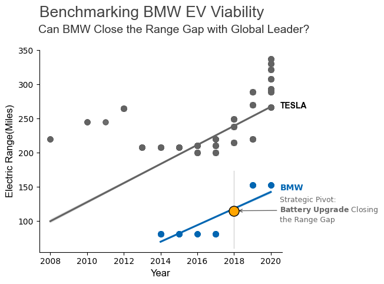

```python
plot=data_csv[(data_csv['Make'].isin(['BMW','TESLA']))&
    (data_csv['Model Year']>=0)&
    (data_csv['Electric Vehicle Type']=='BEV')&
    (data_csv['Electric Range']>0)]
g=sns.lmplot(
    data=plot,x='Model Year',y='Electric Range',hue='Make',palette={'BMW':'#0066b2','TESLA':'#636363'},
    scatter_kws={'alpha':0.3,'s':40},
    height=5,
    aspect=1.2,
    legend=False
)
plt.title('Benchmarking BMW EV Viability',fontsize=16,pad=40,loc='left',size=19,color='#444444',family='Arial'),
plt.ylabel('Electric Range(Miles)',fontsize=12,family='Arial')
plt.xlabel('Year',fontsize=12,family='Arial')
plt.text(2020.5,265,'TESLA',fontweight='bold',family='Arial')
plt.suptitle('Can BMW Close the Range Gap with Global Leader?',size=14,x=0.5,y=0.94,color='#333333',family='Arial')
plt.text(2020.5,145,'BMW',color='#0066b2',fontweight='bold')
plt.tight_layout(rect=[0,0.05,0.9,1.1])
plt.scatter(2018,115,color='orange',s=150,edgecolor='black',zorder=5)
plt.annotate('Strategic Pivot:\n$\\mathbf{Battery\\ Upgrade}$ Closing\nthe Range Gap',xy=(2018.15,115),
             xytext=(2020.5,98),
            arrowprops=dict(
                           arrowstyle='->',alpha=0.6,color='black'),
            fontsize=9,alpha=0.6)
plt.axvline(x=2018,ymin=0.02,ymax=0.4,color='lightgray',zorder=0,linewidth=1)
plt.show()
```

### Visual Highlights

Used Gestalt Principle of Similarity.Utilized dual trend lines to create visual race.

Removed background grid & frame border to focus on datapoints.

Gestalt Principle of focal point.Integrated a hightlighted 2018 pivot with orange marker act as hero of chart.

Placed labels directly at the end of lines,to reduce the cognitive effort(Principle of Proximity).

# Mapping BMW's Global Production Ecosystem

### Source:

Adapted from(BMW Group Report 2024,p.41)

link:https://www.bmwgroup.com/en/report/2024/downloads/index.html

ISO-3 code link:https://www.iban.com/country-codes

```python
Data=pd.DataFrame({
    'Country':['Germany','Austria','UK',
               'USA','China','Mexico','South Africa','Brazil',
               'India','Thailand','Hungary','Portugal','Japan',
               'South Korea','China','Vietnam','India','Indonesia','Egypt','Malaysia'],
    'Type':['Owned Plant']*14+['Partner Plant']*6,
    'Iso_Code':['DEU','AUT','GBR','USA','CHN','MEX',
                'ZAF','BRA','IND','THA','HUN','PRT',
                'JPN','KOR','CHN','VNM','IND','IDN','EGY','MYS']
})
Data.sample(1)
```

|  | Country | Type | Iso_Code |
| --- | --- | --- | --- |
| 14 | China | Partner Plant | CHN |

```python
fig=px.scatter_geo(Data,
                  locations='Iso_Code',
                  locationmode='ISO-3',
                  hover_name='Country',
                  height=550,width=680,
                   color='Type',
                   color_discrete_map={
                       'Owned Plant':'#0066b3',
                       'Partner Plant':'#6e6e6e'},
                  template='plotly_white',
                  projection='miller')
fig.update_traces(marker=dict(size=14,symbol='circle-dot',
                             line=dict(width=1.5,
                                      color='white')))
fig.update_geos(fitbounds='locations',
               showframe=False,
               showcoastlines=False,
               showcountries=True,
               countrycolor='white',
               landcolor='rgb(204,204,204)')
fig.update_layout(
    title=dict(font_color='black',font_size=30),
    margin=dict(r=100,l=20,t=150,b=0),
    showlegend=False
)
fig.add_annotation(
    xref='paper',
    yref='paper',
    x=0,
    y=1.325,
    text='''<span style='font-size:30;color:#333333;'><b>BMW is Ready for EV Era</b></span><br><span style='color:#0066b3;'><b>Owned
Plants</b></span> ensures investments directly convert into EV capacity''',
    showarrow=False,
    font=dict(size=17,color='#444444'),
    align='left'
)
fig.add_shape(
    type='line',
    x0=0,x1=1.1,
    y0=1.17,y1=1.17,
    line=dict(color='black',width=0.8)
)
fig.add_annotation(
    xref='paper',
    yref='paper',
    text="<b><span style='color:#0066b3;'>14 Owned Plants</b></span> locations provide<br>the direct control,needed to move<br>from ICE to EV as demand evolves.",
    align='left',
    font=dict(size=11,color='gray'),
    x=0,
    y=1.16,
    showarrow=False
)
fig.add_annotation(
    xref='paper',
    yref='paper',
    text='<b>6 Partner</b> sites provide <br>flexibility,allowing BMW to enter <br>new markets quickly <b>without <br>heavy fixed asset risks</b>.',
    align='left',
    font=dict(size=11,color='gray'),
    x=0.9,
    y=1.16,
    showarrow=False
)

fig.show()
```

[figure not shown]

### Visual Highlights

Gestalt Principle of similarity is used(Blue color for owned,gray for partner),which allow viewer to instally categorize the each individual label

Used gray for landcolor to remove background noise.

(Gestalt Principle of Proximity)Placed text labels directly to relevant regions to create a strong visual links.

### Insight

While first two charts showed the Why(Market Demand) and the What(Product Range),this chart show the How(Manufacturing Capability).In this era,batteries are heavy and expensive to ship.Heaving a global ecosystem mean BMW can produce the cars close to where they are sold.

# Identifying High Efficiency Growth Hubs(2023 vs 2024)

### Source:

Adapted from (BMW Report 2024,p.62)

link:https://www.bmwgroup.com/en/report/2024/downloads/index.html

```python
Data2=pd.DataFrame({
    'Plants':['Spartanburg(USA)','Dadong(China)','Regensburg(Germany)',
              'Dingolfing(Germany)','Tiexi(China)','Leipzig(Germany)',
              'Munich(Germany)','Oxford(UK)','San Luis Potosi(Mexico)',
              'Rosslyn(South Africa)','Chennai(India)','Araquari(Brazil)',
              'Rayong(Thailand)','Goodwood(UK)','Debrecen(Hungary)',
              'Zhangjiagang(China)','Born-VDL Nedcar(Netherlands)',
              'GrazMagna Steyr(Austria)','Partner Plants'],
    '2024':[396117,343973,342521,297761,284045,246195,200590,
            110939,95236,55516,14568,11472,8666,5924,92,67561,
            7515,10463,14676],
    '2023':[410793,420586,238301,291907,307972,188199,217480,
            185400,117576,68238,15264,10608,13044,6179,'',
            2871,120235,26461,20808]})
Data2.sample(1)
```

|  | Plants | 2024 | 2023 |
| --- | --- | --- | --- |
| 5 | Leipzig(Germany) | 246195 | 188199 |

```python
Data2=Data2.sort_values(by='2024',ascending=True)
colors=['#595959']*(len(Data2)-3)+['#0066b3']*1+['Gray']*2
yfontcolor=['black']*(len(Data2)-3)+['#0066b3']*1+['black']*2
styled_ticks=[f"<span style='color:{color}'><b>{name}</b></span>"if color != 'black'else name for name,color in zip(Data2['Plants'],yfontcolor)]
bar_labels1=[f"{val/1000:.0f}k"if name=="Regensburg(Germany)" else "" for name, val in zip(Data2['Plants'],Data2['2024'])]
bar_labels2=[f"{val/1000:.0f}k"if name=="Regensburg(Germany)" else "" for name, val in zip(Data2['Plants'],Data2['2023'])]
fig=go.Figure()
fig.add_trace(go.Bar(
    y=Data2['Plants'],
    x=Data2['2024'],
    name='2024',
    text=bar_labels1,
    orientation='h',
    marker_color=colors,
    opacity=0.5
))
fig.add_trace(go.Bar(
    y=Data2['Plants'],
    x=Data2['2023'],
    name='2023',
    text=bar_labels2,
    textposition='outside',
    orientation='h',
    marker_color='grey',
    opacity=0.6
))
fig.update_layout(
    title=dict(text='''<span style='font size:20px;color:rgb(102,102,102);'><b> Identifying High Efficiency
Growth Hubs(<span style='color:#595959;'>2023</span> vs <span style='color:#0066b3;'>2024</span>)</b></span><br>
<sup>Most Plants Slowed Down While Key German Hubs Broke Records</sup>''',
              font_size=25,
              font_color='rgb(102,102,102)'),
    barmode='overlay',
    template='plotly_white',
    height=600,width=1000,
    showlegend=False,
    xaxis=dict(
        showgrid=False,
        showticklabels=False,
    ),
    yaxis=dict(
    tickmode='array',
    tickvals=list(range(len(Data2))),
    ticktext=styled_ticks,
        color='black'
    ),margin=dict(t=130,r=150,l=0,b=0))
fig.add_annotation(
    text="Now it's <b>Global Mandate,<br>need to accelerate investment</b><br>in high volume hubs to <b>prevent<br>market erosion.</b>",
    xref='paper',
    yref='paper',
    x=1.054,y=0.57,
    showarrow=False,
    align='left',
    font_color='grey'
)
fig.add_annotation(
    text='''<span style='color:rgb(128,177,211);'><b>Regensburg</b></span> proves that<br>flexibility in production
is<br>paying off,meeting<b><span style='color:rgb(128,177,211);'> electric<br>demand.</span>''',
    xref='x',
    yref='y',
    x=405000,y=13.9,
    showarrow=False,
    align='left',
    font_color='grey'
)
fig.add_annotation(
    xref='paper',
    yref='paper',
    text='in 1000 Units',
    x=-0.18,y=1.08,
    showarrow=False,
    font=dict(size=15,color='gray')
)
fig.add_shape(
    type='line',
    xref='paper',
    yref='paper',
    x0=-0.21,x1=1,
    y0=1.082,y1=1.082,
    line=dict(color='black',width=0.9)
)
fig.show()
```

[figure not shown]

### Visual Highlights

Gestalt Principle of Continuity is used to sort horizontal bar(top to bottom),allowing reader to identify the largest production hubs.

(Gestalt Principle of Focal Point)Strategic color highlighting(Blue to regensburg and gray for others.).Forces eye to focus on the success story.

(Principle of Proximity)Direct labelling to save space and to avoid eye zigzag.

Followed clutter is the enemy rule by removing vertical gridlines.

### Insight

The chart proves that Manufacturing flexibility is working and meeting the electric demand,but other massive plants have slightly slowed down.For a global business,this is a warning sign.That mean company is becoming overly dependent on its European production.This chart should be used to decide where to accelerate investment to ensure they don't lose market.

# The EV Transition-BEV vs Total Market

### Source:

BMW Report 2024,p.81

link:https://www.bmwgroup.com/en/report/2024/downloads/index.html

```python
df=pd.DataFrame({
    'Sale_varient':['BMW Total','BEV','PHEV'],
    '2024':[2200217,368475,164172],
    '2023':[2252793,330197,173878],
    '%_change':[-2.3,11.6,-5.6]
})
df.sample(1)
```

|  | Sale_varient | 2024 | 2023 | %_change |
| --- | --- | --- | --- | --- |
| 0 | BMW Total | 2200217 | 2252793 | -2.3 |

```python
fig=go.Figure()
for i,row in df.iterrows():
    if row['Sale_varient']=='BMW Total':
        shrink_factor=3
    else:
        shrink_factor=0.1
    color='#0066b3' if row['Sale_varient']=='BEV' else '#949494'
    y_plot=[row['2023']/shrink_factor,row['2024']/shrink_factor]
    fig.add_trace(go.Scatter(x=['2023','2024'],
                            y=y_plot,
                            mode='lines+markers+text',
                            line=dict(color=color,
                                     width=4),
                            marker=dict(size=10,color=color),
                            text=[f"{int(row['2023']):,}",f"{int(row['2024']):,}  {row['Sale_varient']}"],
                             textfont=dict(color=color),
                            textposition=["middle left","middle right"],
                            hoverinfo="skip"))
    fig.add_annotation(
        x=0.5,
        y=(y_plot[0]+y_plot[1])/2,
        text=f"{row['%_change']}%",
        showarrow=False,
        font=dict(color=color,
                 size=14,family='Arial Black'),
        yshift=20 if
        row['Sale_varient']=='BEV' else -20
    )
    fig.add_annotation(
        text="# OF UNITS",
        font=dict(color='#949494',size=12),
        xref='paper',
        yref='paper',
        x=0.09,
        y=0.65,
        showarrow=False
    )
    fig.add_annotation(
        text="% CHANGE",
        font=dict(color='#949494',size=12),
        xref='paper',
        yref='paper',
        x=0.4,
        y=0.65,
        showarrow=False
    )
    fig.add_annotation(
        text="<span style='color:#0066b3;'><b>Electrification</b></span> is the Future",
        font=dict(size=24,color='rgb(102,102,102)',family='Arial'),
        xref='paper',
        yref='paper',
        x=0.074,
        y=0.95,
        showarrow=False
    )
    fig.add_annotation(
        text="It's <b>Risky to Invest</b> in Traditional Segments",
        font=dict(size=22,color='rgb(102,102,102)',family='Arial'),
        xref='paper',
        yref='paper',
        x=0.074,
        y=0.89,
        showarrow=False
    )
    fig.add_annotation(
        text='''<b>Total deliveries</b> are contracting despite an<span style='color:#0066b3;'> 11.6%
surge in BEVs</span>,<br>highlighting the risk in legacy segments''',
        font=dict(size=13,color='gray',family='Arial'),
        xref='paper',
        yref='paper',
        align='left',
        x=0.074,
        y=0.82,
        showarrow=False
    )
    fig.update_layout(
        plot_bgcolor='white',
        showlegend=False,
        xaxis=dict(showgrid=False,
                  showline=False,
                   color='#949494',
                  range=[-0.5,2]),
        yaxis=dict(showgrid=False,
                  showticklabels=False,
                  range=[0,7000000]),
        margin=dict(l=0,r=0,t=0,b=30),
        height=400,width=600
    )
fig.show()
```

[figure not shown]

## Visual Highlights

Used Strategic color(Blue for BEV and Muted gray).Instantly directs eye to the BEV.

Direct labeling on axis remove the need of legend.

Remove x,y-axis to follow clutter is enemy principle.

### Insight

The chart explain that BEV growth is not only extra sales,but it is replacing traditional sales.The business must focus 100% of its innovation on BEVs to stabilize the Total line.

# Financial Resilience Amidst Strategic Investment

### Source:

Data Adapted from (BMW Group Report 2024,p.70)

link:https://www.bmwgroup.com/en/report/2024/downloads/index.html

```python
fig=go.Figure()
fig.add_trace(go.Waterfall(
    name='',orientation='v',
    x=['Revenues','Cost of Sales','Operating Exp','Taxes','Net Profit'],
    y=[142.38,-119.49,-11.924,-3.293,7.68],
    measure=['absolute','relative','relative','relative','total'],
    connector=dict(line=dict(color='rgb(63,63,63)',width=1)),
    decreasing=dict(marker=dict(color='rgb(239,154,154)')),
    totals=dict(marker=dict(color='gray'))
))
fig.update_traces(
    text=['143','-121','-12','-2.4','7.6'],
    textposition='outside',
    texttemplate='%{text}'
)
fig.update_layout(
    title='''<span style='font-size:20px;color:red'>Strategic R&D Peak</span> Hits Profitability</span><br><b>External
Capital Needed to Accelerate EV Timeline''',
    title_font=dict(size=20,
                   color='#444444'),
    margin=dict(t=170,b=60),
    yaxis=dict(range=[0,160],
               showticklabels=False,
               showgrid=False,
               tickformat='.0f',
               color='black'),
    xaxis=dict(color='black'),
    showlegend=False,
    template='plotly_white',
    height=600,width=650
)
fig.update_layout(title=dict(
                 yanchor='bottom',
y=0.91))
fig.add_annotation(xref='paper',yref='paper',
                  x=0.365,
                  y=1.23,
                   align='left',
                   showarrow=False,
                  text='''Current revenue is fully committed to future tech,outsourcing investment<br>will bridge the speed gap to market
leadership.<br><br>(in &#8364; Billion)''',
                  font=dict(size=14,color='#333333',family='Arial'))
fig.add_shape(
    type='line',
    x0=0.6,x1=2.4,
    y0=150,y1=150,
    line=dict(color="#888888",width=1.5)
    )
fig.add_shape(type='circle',x0=0.56,x1=0.6,y0=149.3,y1=151,
             line=dict(color='gray',width=1.5))
fig.add_shape(type='circle',x0=2.40,x1=2.44,y0=149.3,y1=151,
line=dict(color='gray',width=1.5))
fig.add_annotation(
    text='Strategic R&D Deployment;<br>133B invested in EV future.',
    xref='paper',
    yref='paper',
    x=0.4,
    y=1.03,
    showarrow=False,
    font=dict(size=11,color='gray')
)
fig.add_annotation(
    text='<b>7.6B Net Profit</b> remains healthy,but is not sufficient to fully fund the Accelerated EV timeline.',
    xref='paper',
yref='paper',
x=1.1,
y=-0.12,
    yanchor='bottom',
    showarrow=False,
    font=dict(color='#444444')
)
fig.show()
```

[figure not shown]

## Visual Highlights

(Gestalt Principle of Continuity)used a waterfall chart to show step down effect of expense.

(Strategic color Contrast)Used red to highlight the hero of the chart and gray for the other.

Direct data labeling on bar follow clutter is enemy principle.

Used Annotation for better storytelling.

### Insight

The Waterfall chart is a financial reality check.The insight here is that the net profit is not enough to pay for the massive scale up required to beat Global Leader or secure raw materials.It justify that company needs external capital for transition.

# Final Discussion and Conclusion

### Pipeline Strengths and Limitations

#### Strengths

Integrates financial,manufacturing and competitive data to build holistic corporate case.

Moves beyond descriptive statistics to provide executable business recommendations.

Insight driven titles answer investor immediately.

### Limitations

The map show Plant is EV ready,but doesn't show actual conversion percentage.

Waterfall chart show moment in time analysis only,doesn't show when high expenses will break even.

Focused on Finance and Hardware data,overlooked the workforce transition risk.

## Result

From the charts,it is clear that the company need the investments for 100% BEV production line,because traditional segment is losing market with time.Today,it seems a short steady decline,but long term investment is going to be risky in this segment.So,Electrification is not choice its the future of the company.

## Data Driven Recommendations

Reallocate resources from declining PHEV segments into high growth BEV to maintain current momentum.

Replicate the high efficiency framework of record breaking plant to ensure rapid EV scaling.

Must Prioritize Electric range to close the gap with market leader.